# Supplement: model fits and diagnostics

Dylan M. Glaser, Brendan M. Connors, Kaitlyn Dionne and Ann-Marie Huang

This document describes fits from both state-space Ricker spawner-recruit models used fit in the [Research Document](https://publications.gc.ca/collections/collection_2025/mpo-dfo/fs70-5/Fs70-5-2024-063-eng.pdf):

Glaser, D.M., Connors, B.M., Dionne, K., and Huang, A.M. 2024. Estimating Precautionary Approach reference points and assessing consequences of harvest control rules for Fraser River Pink Salmon (*Oncorhynchus gorbuscha*). DFO Can. Sci. Advis. Sec. Res. Doc. 2024/063. iv + 31 p.

Two state-space spawner-recruit models were fit in this paper that serve different purposes. First, a Ricker model with autoregressive (AR1) recruitment residuals was fit to estimate biological benchmarks ($S_{gen}$, $S_{MSY}$, and $U_{MSY}$), then a model with time-varying productivity (Ricker $\alpha$ parameter) was fit in order to condition the biological submodel on recent population dynamics in the closed-loop forward simulation. Data and code to reproduce the analysis and report is available in this [GitHub repository](https://github.com/Pacific-salmon-assess/FR-PK-ResDoc/tree/main), where you can see the [R code](https://github.com/Pacific-salmon-assess/FR-PK-ResDoc/blob/main/analysis/R/fit-sr-stan.R) to run the models, and the [models](https://github.com/Pacific-salmon-assess/FR-PK-ResDoc/tree/main/analysis/Stan) themselves.

# 1 Diagnostics

We fit the spawner-recruitment model in a Bayesian estimation framework with Stan (Carpenter et al. 2017; Stan Development Team 2023), which implements the No-U-Turn Hamiltonian Markov chain Monte Carlo algorithm (Hoffman and Gelman 2014) for Bayesian statistical inference to generate a joint posterior probability distribution of all unknowns in the model. We sampled from 4 chains with 2,000 iterations each and discarded the first half as warm-up. We assessed chain convergence visually via trace plots and by ensuring that $\hat{R}$ (potential scale reduction factor; Vehtari et al. (2021)) was less than 1.01 and that the effective sample size was greater than 400. Posterior predictive checks were used to make sure the model returned known values, by simulating new datasets and checking how similar they were to our observed data.

## 1.1 AR1

### 1.1.1 Trace plots

These should be clearly mixed, with no single distribution deviating from others (left column), and no chains exploring a strange space for a few iterations (right column).

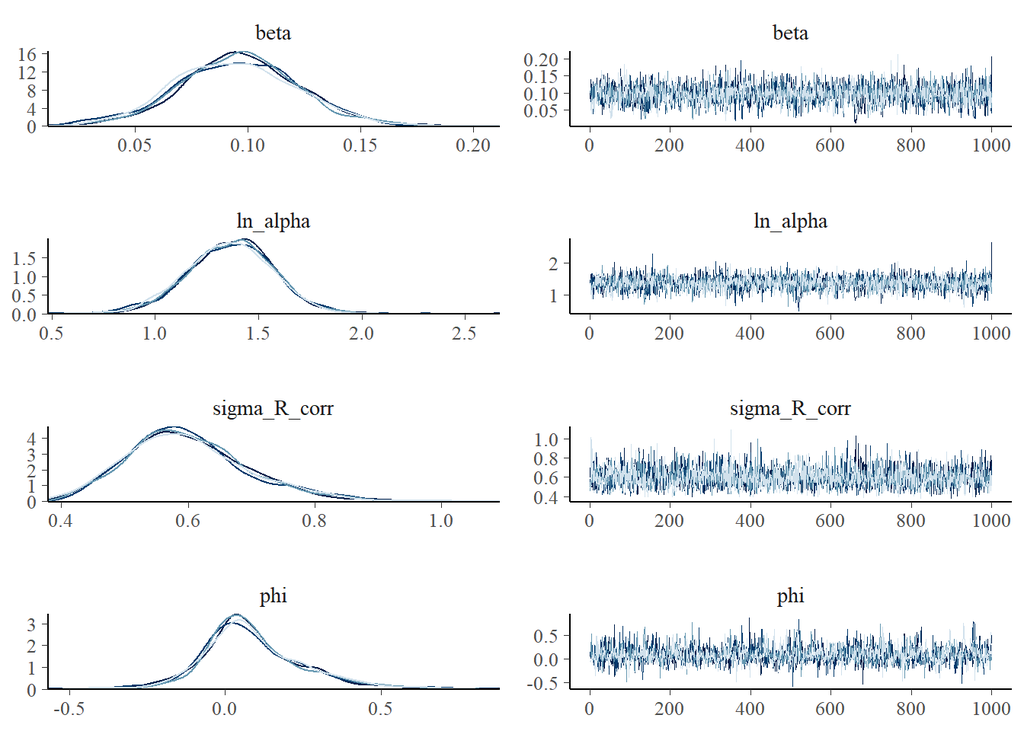

Density overlays (left) and trace plots (right) for leading parameters in the Ricker AR1 model.

These appear well mixed.

### 1.1.2 $\hat{R}$

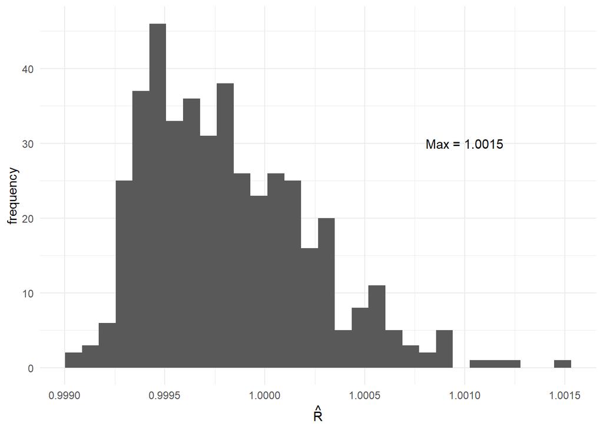

R-hat values from the Ricker AR1 model.

### 1.1.3 Effective sample size

To know we are getting viable estimates, we want the effective sample size to be at least 10% of the total iterations.

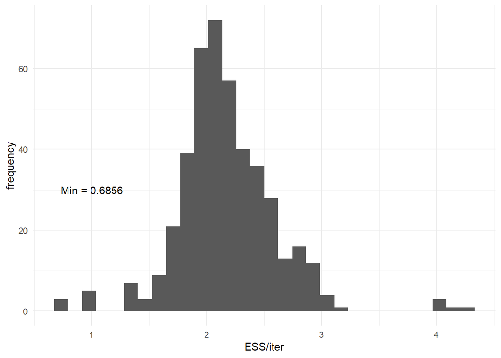

Effective sample size from the Ricker AR1 model.

### 1.1.4 Posterior predictive check

Here we see if the parameters return data similar to ours by using random number generation in the `generated quantities` block of our Stan models. We want the random simulations (light blue lines), to fall near the distribution of our observed data (dark blue line).

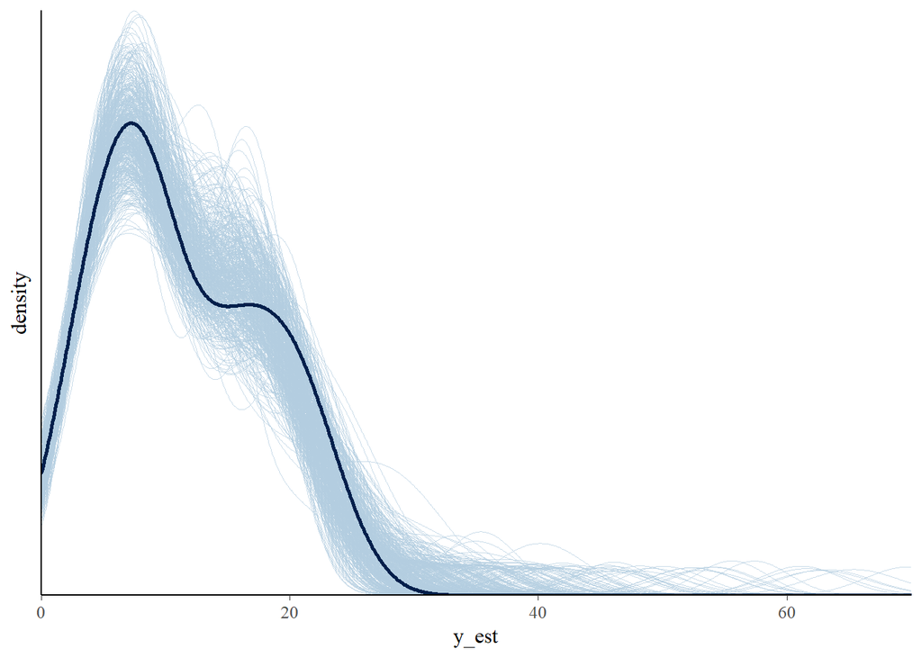

Posterior predictive check from the Ricker AR1 model.

## 1.2 Time-varying productivity

### 1.2.1 Trace plots

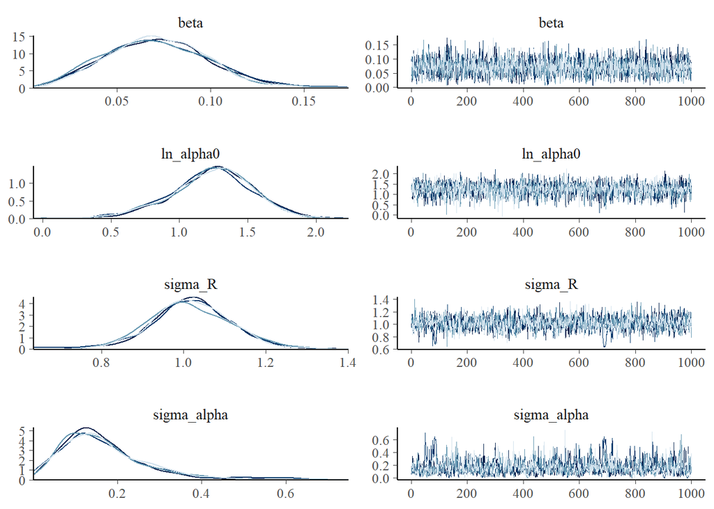

Density overlays (left) and trace plots (right) for leading parameters in the time-varying productivity Ricker model.

### 1.2.2 $\hat{R}$

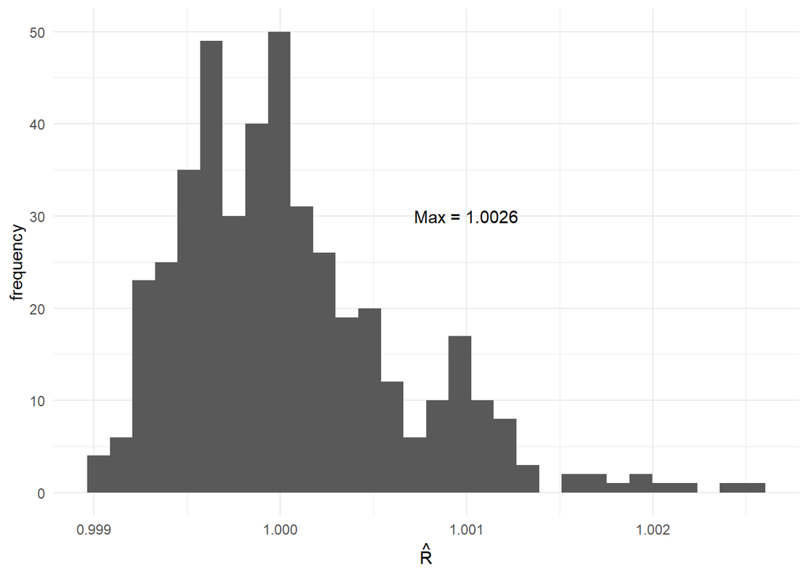

R-hat values from the time-varying productivity Ricker model.

### 1.2.3 Effective sample size

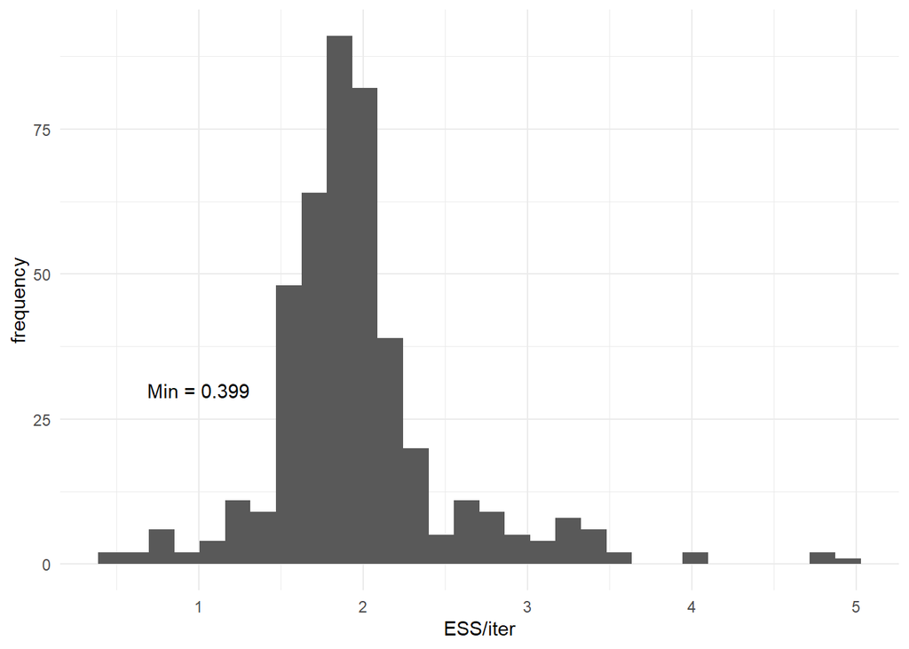

Effective sample size from the time-varying productivity Ricker model.

### 1.2.4 Posterior predictive check

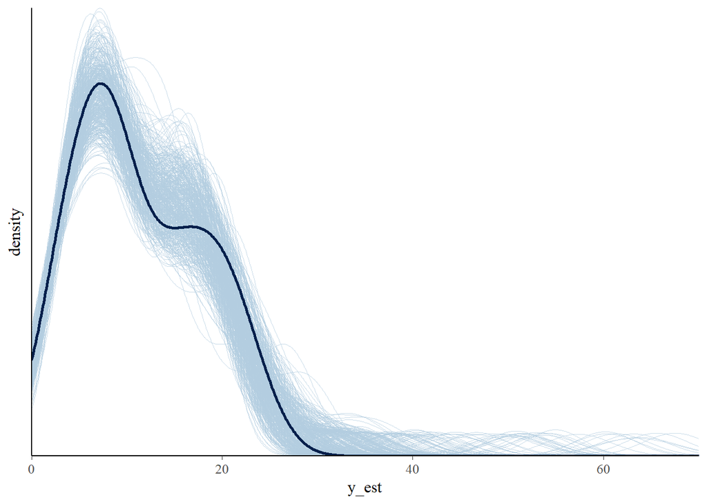

Posterior predictive check from the time-varying productivity Ricker model.

# 2 Fits

We already got an understanding of the posterior distributions by looking at how chains mixed above, and if you want to look at ALL the posteriors from each model you can run the lines with the `launch_shinystan()` function in the [R code](https://github.com/Pacific-salmon-assess/FR-PK-ResDoc/blob/main/analysis/R/fit-sr-stan.R).

It can also be useful to look at the data, and predictions that were made in the observation model.

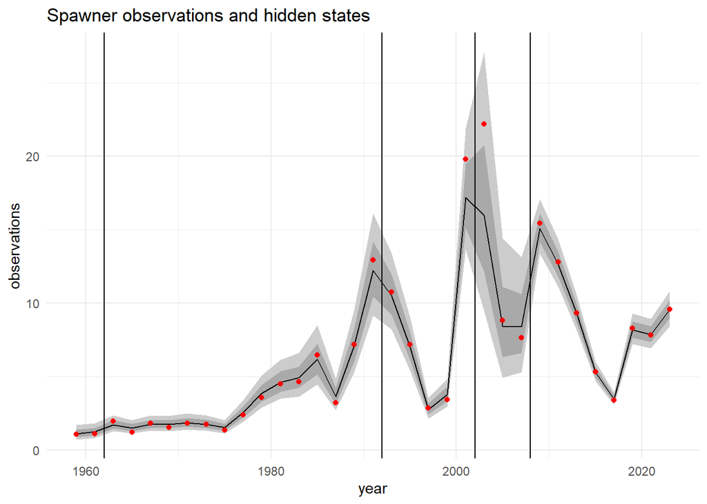

Spawner data (red dots) and latent (i.e. hidden or estimated) states for spawners in the Ricker AR1 model, where vertical lines mark changes in sampling regimes.

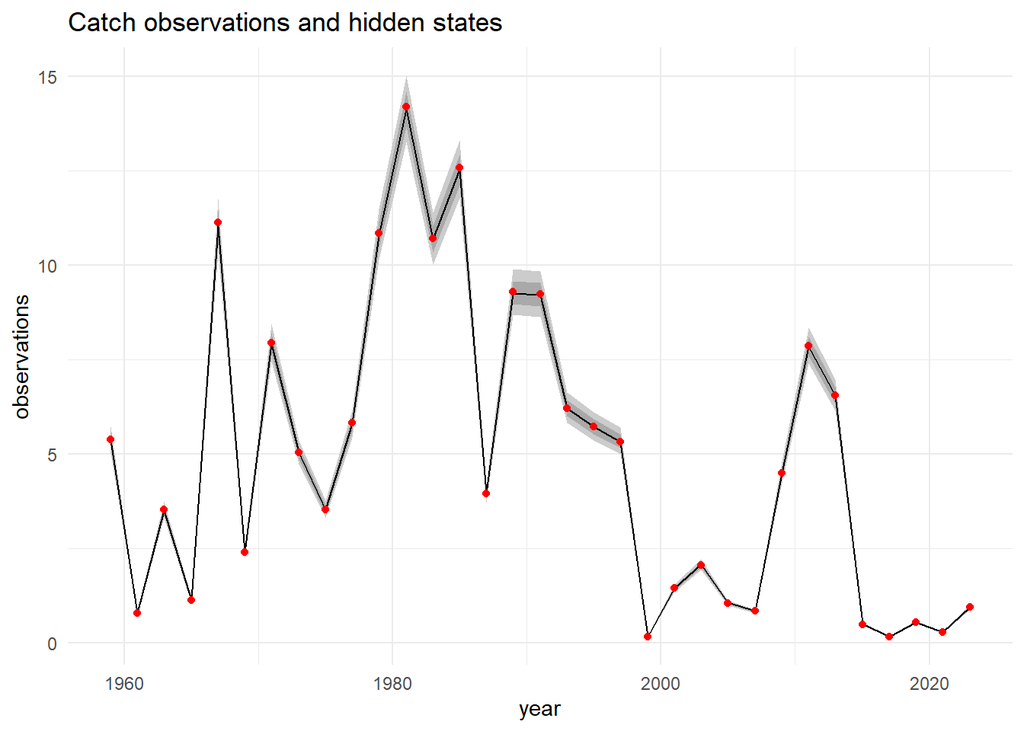

Catch data (red dots) and latent (i.e. hidden or estimated) states for spawners in the Ricker AR1 model.

Notice how the bands around catch are much tighter than the spawners, this is because we assumed a relatively narrow CV of 5% for this data, rather than spawner estimates that varied between 10 to 50% CVs.

## 2.1 Annual productivity

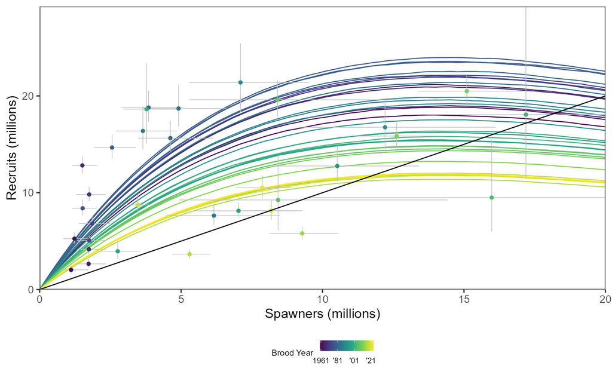

Deterministic fits from annual estimates of Ricker alpha parameter in the time-varying model.

# References

Carpenter, Bob, Andrew Gelman, Matthew D. Hoffman, Daniel Lee, Ben Goodrich, Michael Betancourt, Marcus Brubaker, Jiqiang Guo, Peter Li, and Allen Riddell. 2017. “Stan: A Probabilistic Programming Language.” *Journal of Statistical Software* 76 (1). https://doi.org/10.18637/jss.v076.i01.

Hoffman, Matthew D., and Andrew Gelman. 2014. “The No-U-Turn Sampler: Adaptively Setting Path Lengths in Hamiltonian Monte Carlo.” *Journal of Machine Learning Research* 15: 1593–623. https://jmlr.org/papers/volume15/hoffman14a/hoffman14a.pdf.

Stan Development Team. 2023. “Rstan: The R Interface to Stan.” https://mc-stan.org/users/interfaces/rstan.

Vehtari, Aki, Andrew Gelman, Daniel Simpson, Bob Carpenter, and Paul-Christian Burkner. 2021. “Rank-Normalization, Folding, and Localization: An Improved R-Hat for Assessing Convergence of MCMC (with Discussion).” *Bayesian Analysis* 16 (2): 667–718. https://doi.org/10.1214/20-BA1221.